# Question 4: Volatility and GARCH Estimates

TC Baltazar (19776209)

December 2021

# Introduction

This section aims to use currency data to firstly compare the volatility of the ZAR relative to other currencies, to determine whether it has been ‘one of the most volatile currencies’ over the past few years. And secondly, to examine whether the ZAR benefits from a strong dollar (ie during periods of risk-on sentiment). Intuitively, because the ZAR is such a liquid currency, and SA has a highly developed financial system- relative to other EME’s, but especially when compared to other African countries- the ZAR should be one of the first EM currencies that investors flock to when EM risk is perceived low (ie when the dollar is strong).

# Data

The data sourced for this analysis exclusively relates to currencies. cncy contains spot rates for 41 different currencies relative to the USD. cncy_Carry and cncy_value are proxy measures, based on Deutsche bank indexes, for the returns of carry trade and value strategies, respectively. Currency implied volatility is captured by cncyIV, and has values for 32 currencies. Finally, bbdxy contains data from the Bloomberg Dollar Spot Index, which ‘tracks the performance of ten leading global currencies’ relative to the US Dollar.

# Exploratory and Correlation Analysis

Plotting variables to see their, historical, movements.

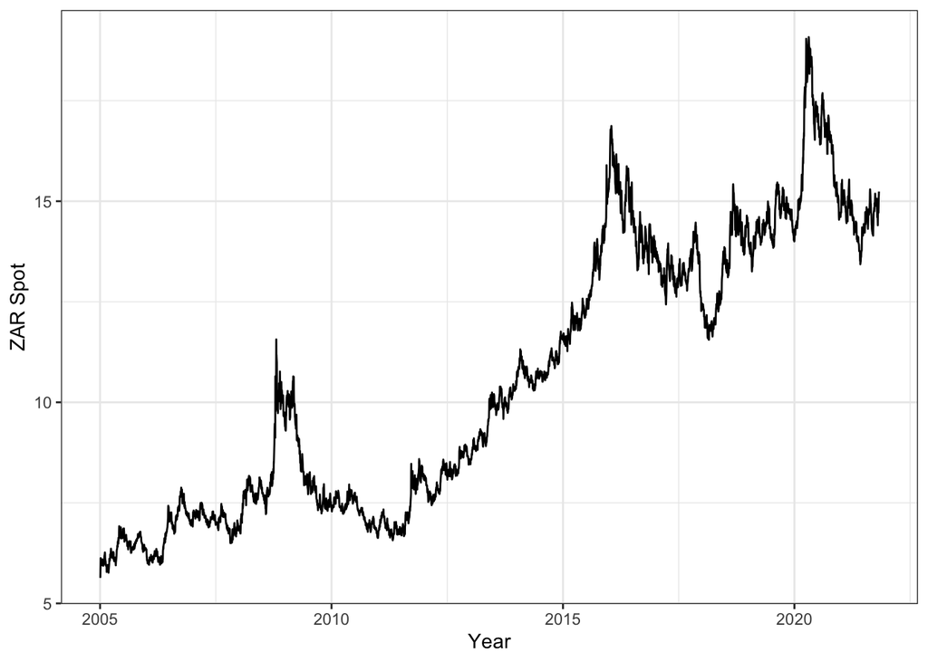

Figure 1: ZAR Spot

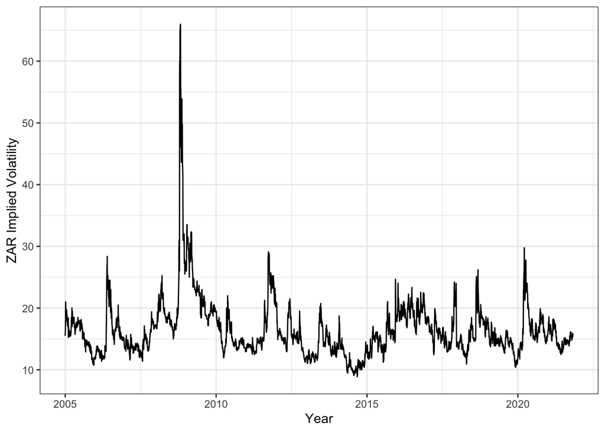

Figure 2: ZAR Implied Volatility

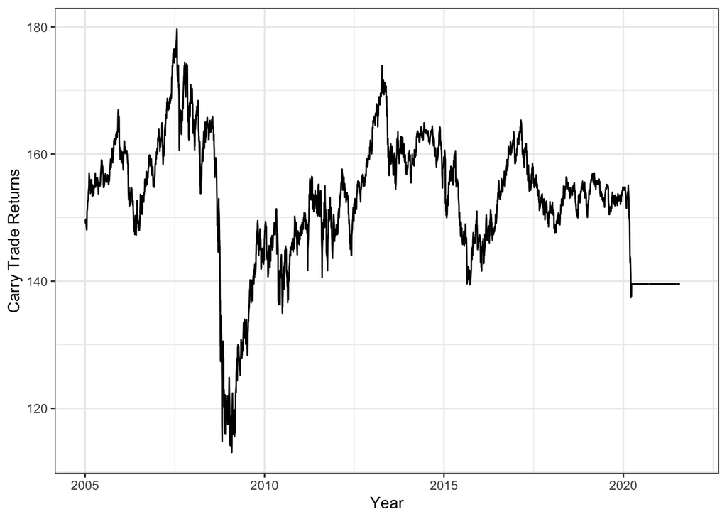

Figure 3: Carry Trade Returns

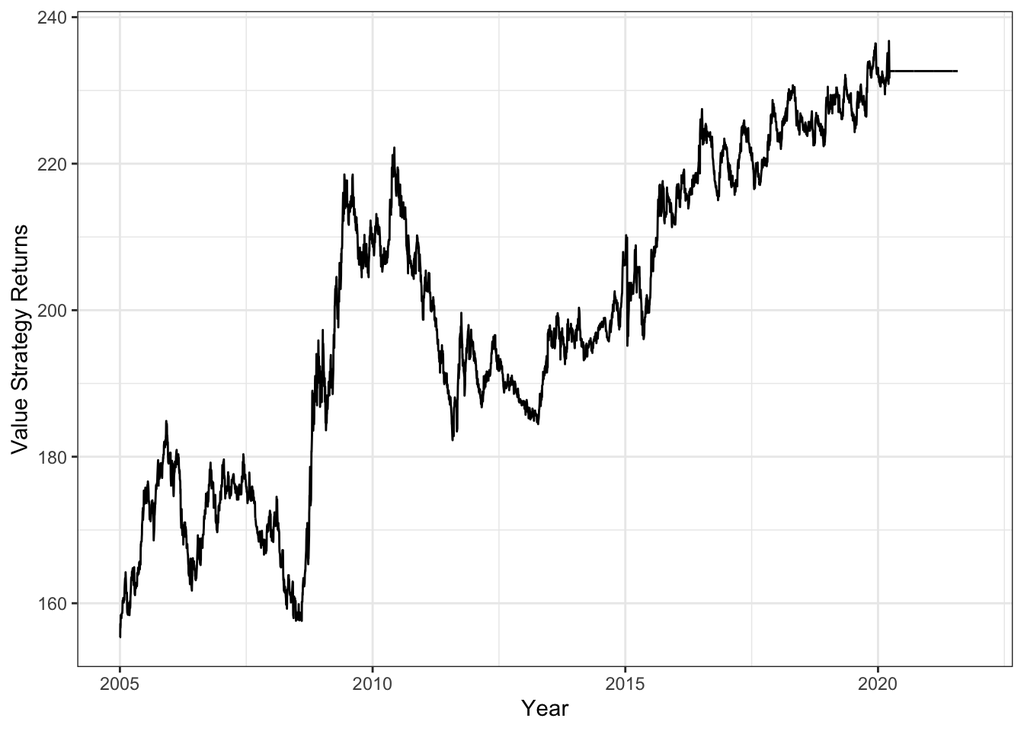

Figure 4: Value Strategy Returns

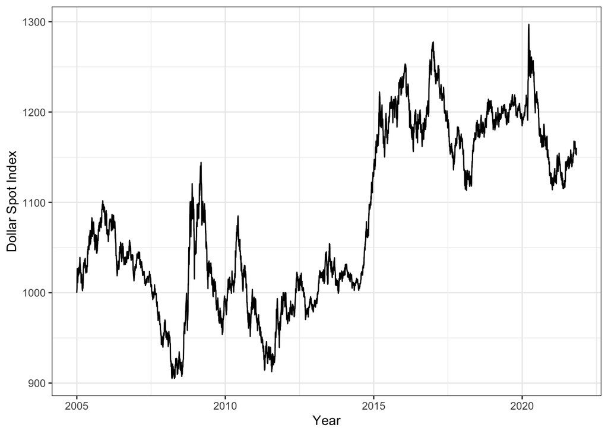

Figure 5: Bloomberg Dollar Spot Index

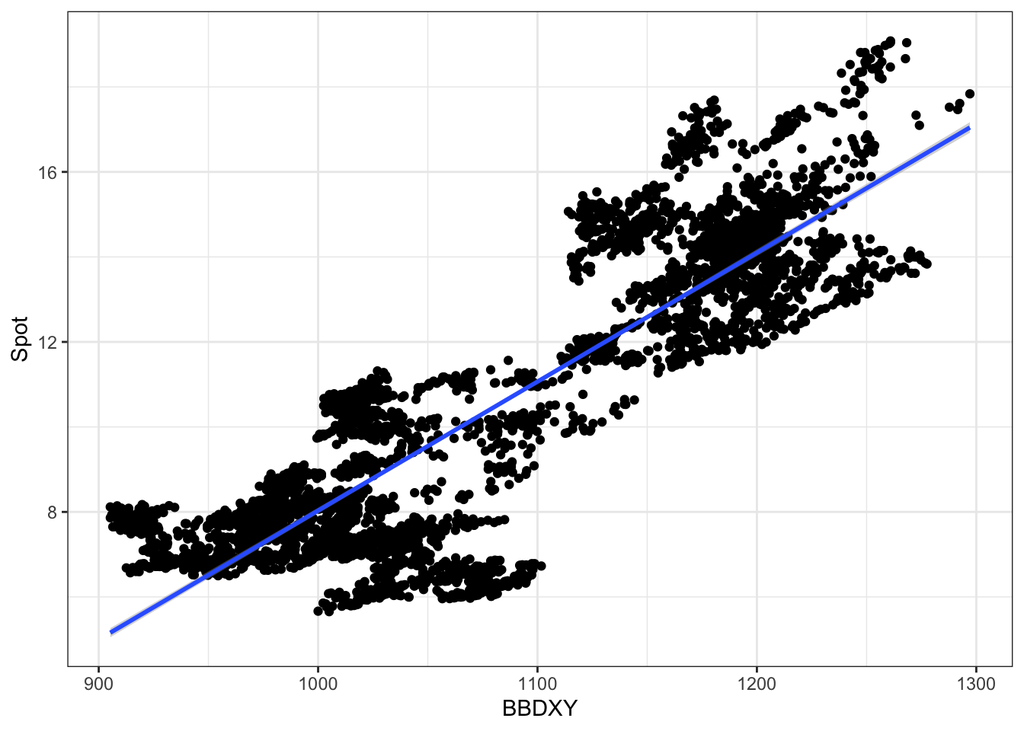

Figure 6: Relationship between ZAR Spot and Dollar Spot Index